# co2_1

2024-02-11

## Co2 emissions etc

Note: you can’t just include variables from the global environment, the document has to be reproducible by itself, therefore you have to load all the data, create pltos etc here - but - it doesn’t have to be visible, you can hide the code with {r, echo=FALSE}

### General analysis over time

First, we want to check if any very general trends of co2 emissions can be seen in the whole dataset. For that, we can plot the amount of co2 released throughout time, for every country in the dataset.

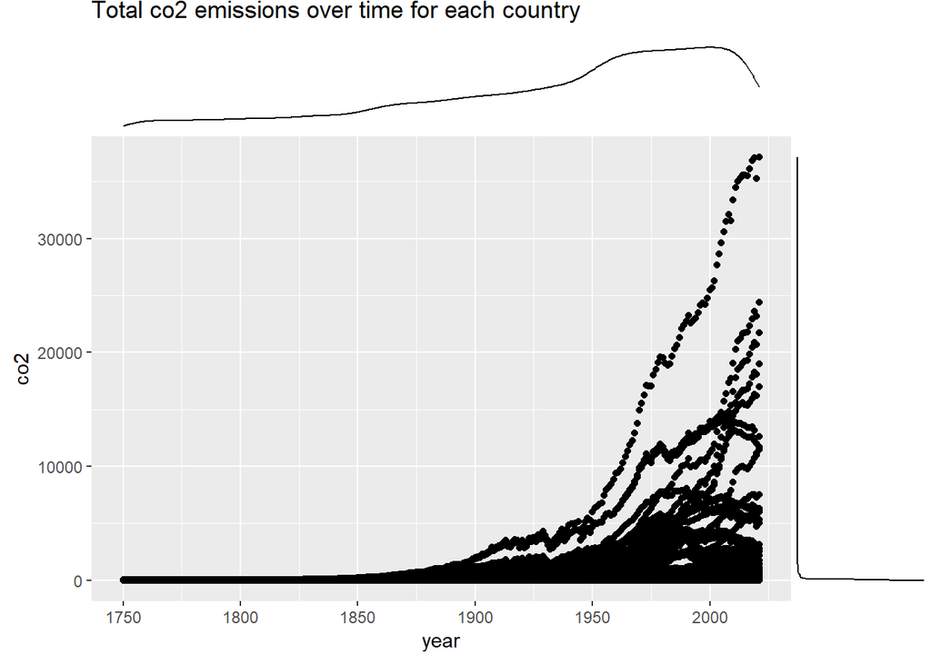

Clearly, we can see, since about the start of the 20th century, some countries start to overshadow others in terms of emissions. From the distribution of year values above the graph, we can also see, for the earlier years of the dataset, a lot of values are missing.

It is also worth noting, in the dataset, beside countries present are grouped statristics for continents and important regions, which, for further analysis, were separated from the main dataset, to be analyzed separately, and possibly in comparison to individual countries.

To limit our focus to the key players, let’s look at the top 10 countries, by the sum of emissions released over time.

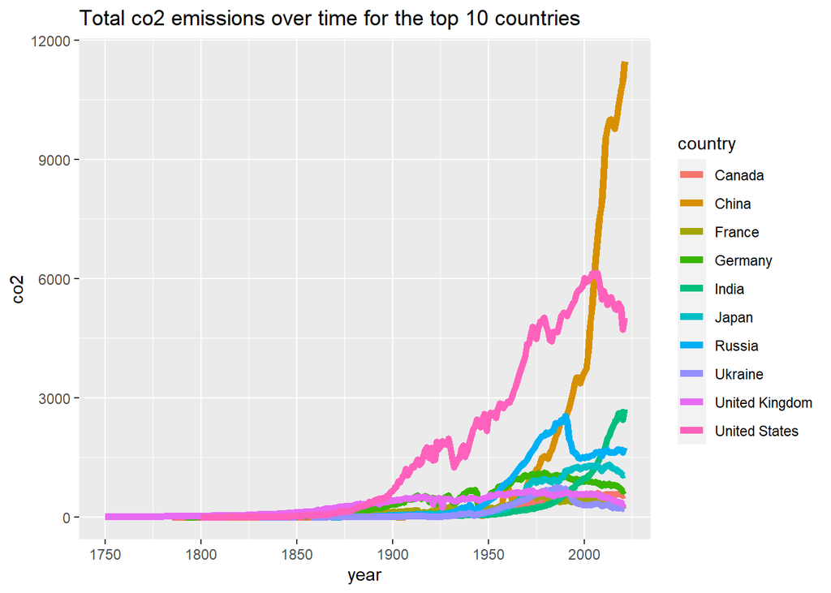

Facet by countries

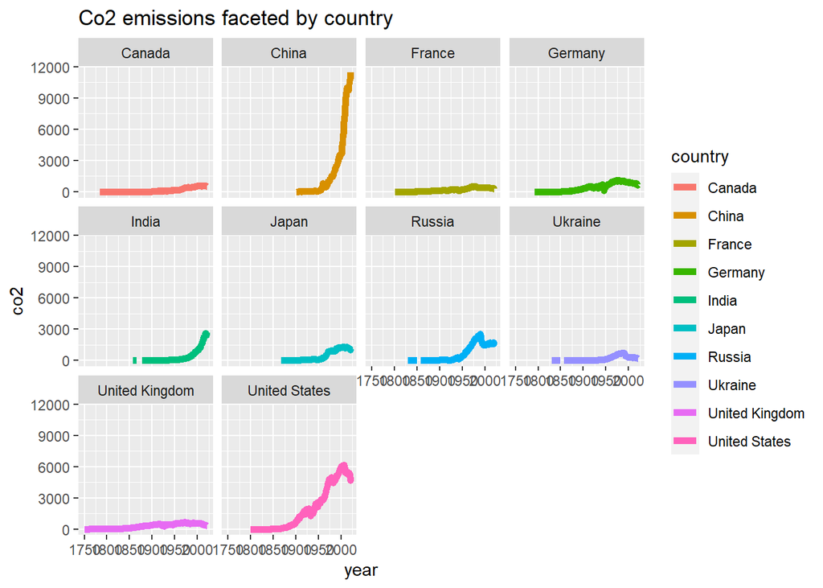

Let’s look at some Individual countries

United States, seems to have had an interesting relation with co2 emissions. Very Whilst the general trend is upward, for about 15 yers now, it has turned downwards. The influence of important global events can also be seen.

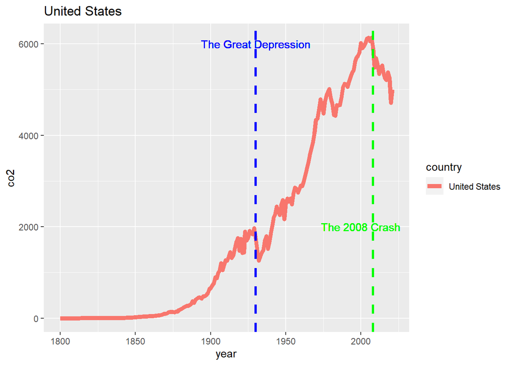

Germany, while on a much smaller (about 1/6) scale, follows a very similar trend of strong emission rise, then a downwards trend in the 21st century.

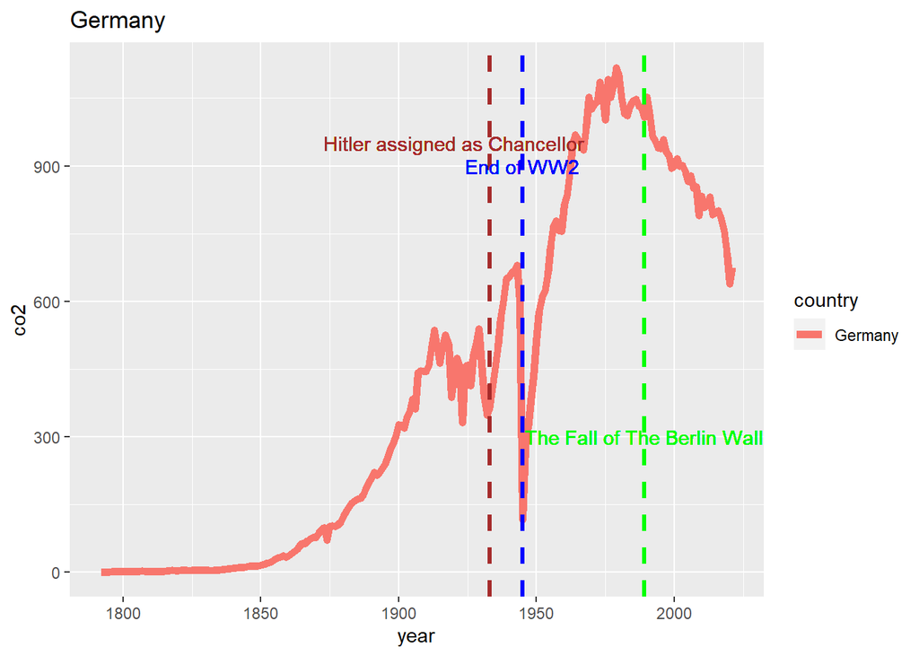

For a different kind of trend, we can, for example look at China:

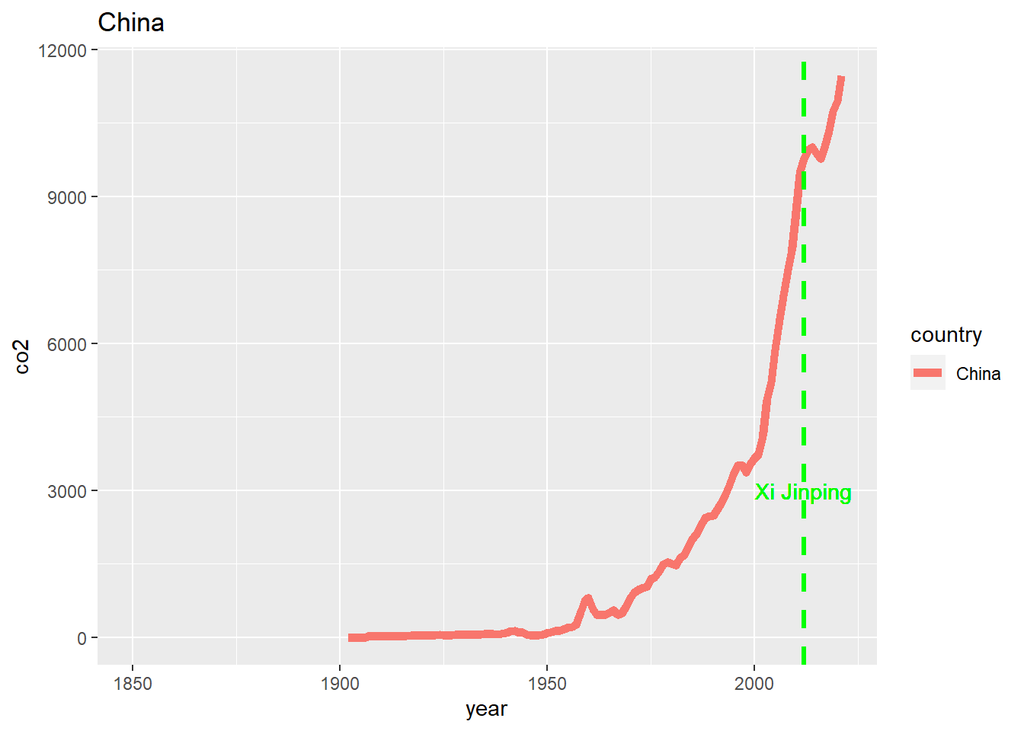

Bottom 10 countries, notice that for a lot of these data is missing, which might contribute to their lower scores, but the scale of emissions is so small, that’s probably not the case.

```
##  [1] "Antarctica"                     "Leeward Islands (GCP)"
##  [3] "Puerto Rico"                    "Tuvalu"
##  [5] "Niue"                           "Saint Helena"
##  [7] "St. Kitts-Nevis-Anguilla (GCP)" "Wallis and Futuna"
##  [9] "Christmas Island"               "Montserrat"
```

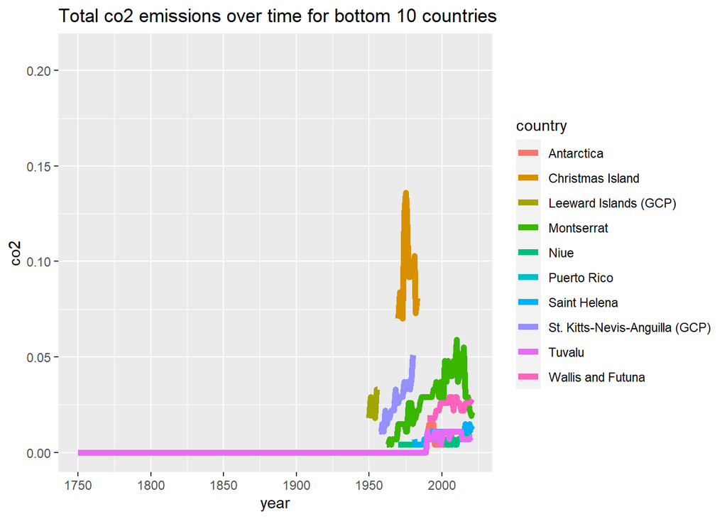

Top 10 countries by population:

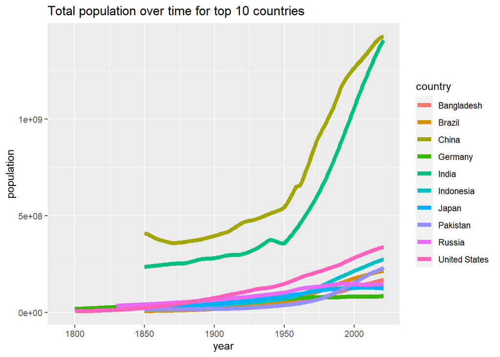

Population and co2 emissions for United States credits to user Megatron’s [answer](https://stackoverflow.com/a/51844068)

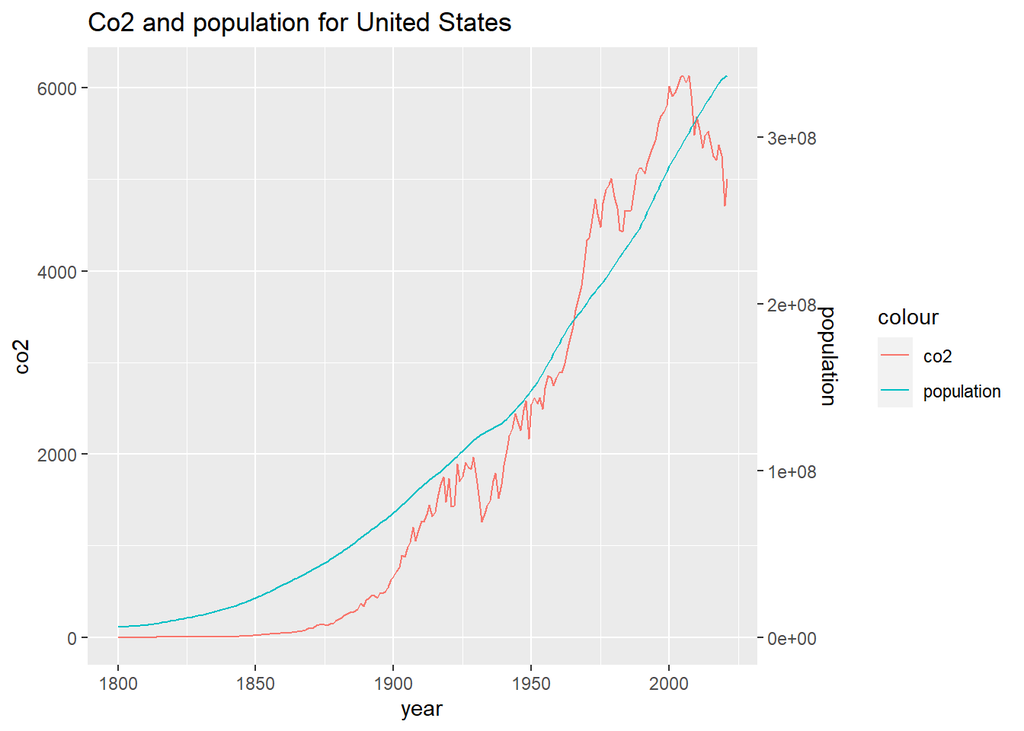

Top 10 countries by co2 vs rest of world

```
## # A tibble: 272 × 2
##     year total_co2
##    <dbl>     <dbl>
##  1  1750      9.35
##  2  1751      9.35
##  3  1752      9.35
##  4  1753      9.35
##  5  1754      9.36
##  6  1755      9.36
##  7  1756     10.0
##  8  1757     10.0
##  9  1758     10.0
## 10  1759     10.0
## # ℹ 262 more rows
```

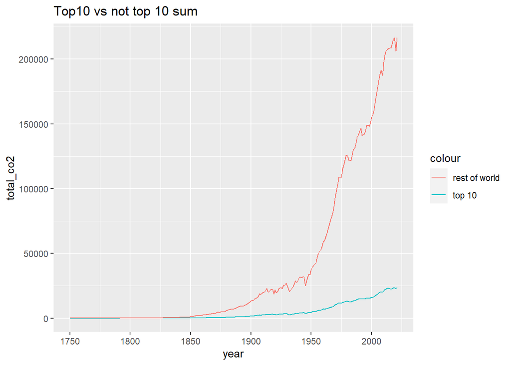

In pie form

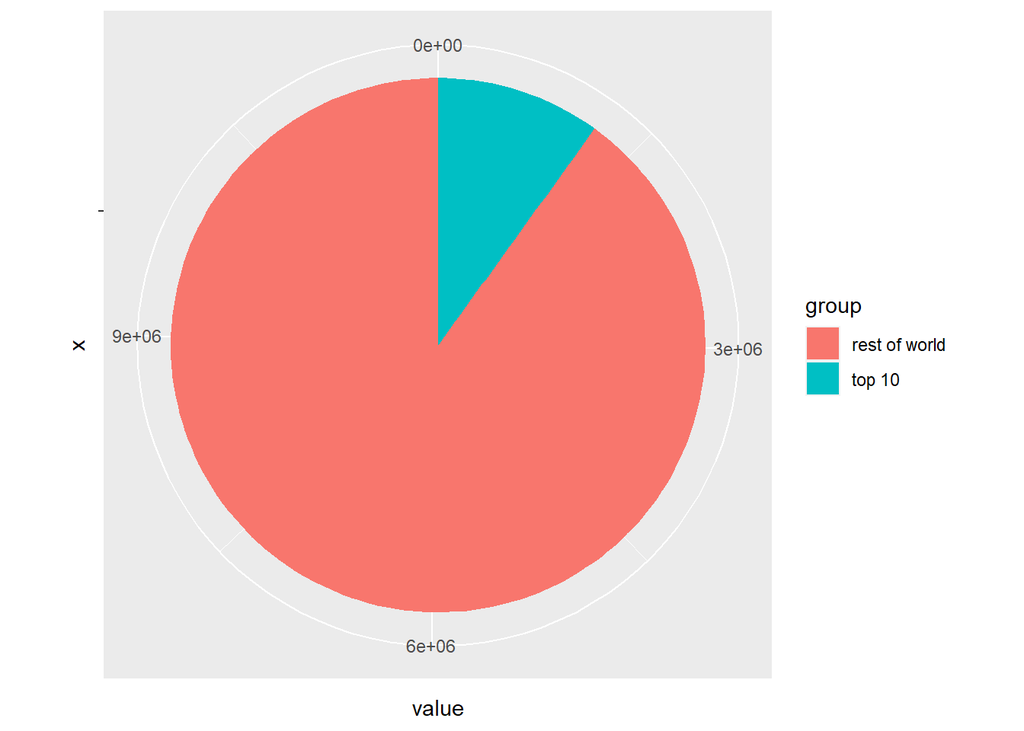

Co2 vs population for the top 10 countries

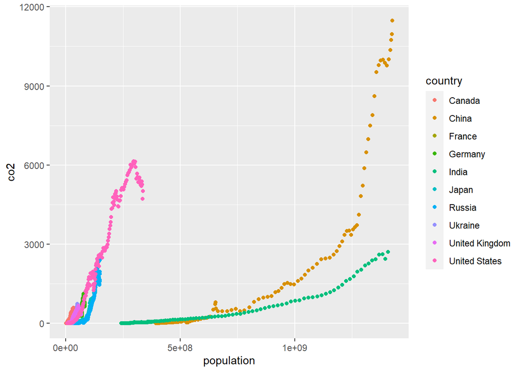

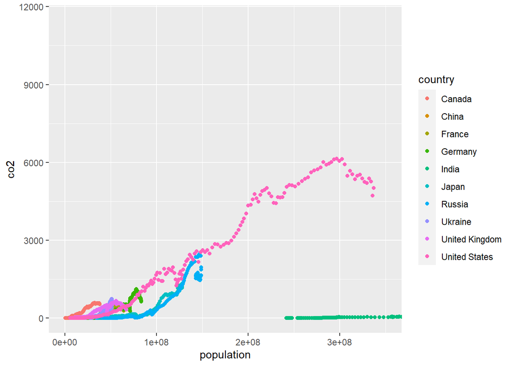